# 10) sector ytd - W1B

23/Feb/2020

1. change the color of the document title to red
2. turn text within the document body red

```
## [1] "getDbSharpes-uom,sector,id:(sector:favorite:W1B"
```

## Sector Metrics Bar Charts

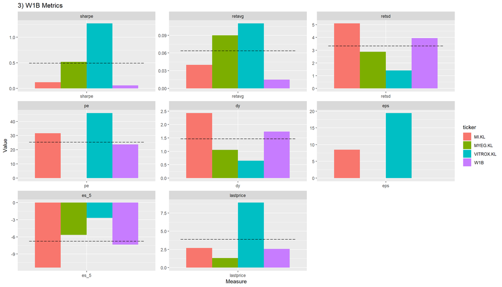

## Conclusion

### Sharpe Ratio (top left)

1. Good performance stocks have sharpe > 1 eg
   - **Vitrox**
2. Average performance stock is
   - **MyEG** (weak ratio)
3. Weak stocks are
   - **MI**
   - **Group**
4. Poor performancers have negative sharpe ratio eg
   - **serbadk** (not in the list)

### Expected Shortfall (5%) (bottom left)

1. High risk stocks that have big volatility eg
   - **MI**
   - **Group**
   - also reported in standard deviation, above target line (top right)

### PE (Valuation)

1. All stocks have high PE ratio (2nd row, left) except
   - **MyEG**

## Risk Reward Charts

```
## $`1`
```

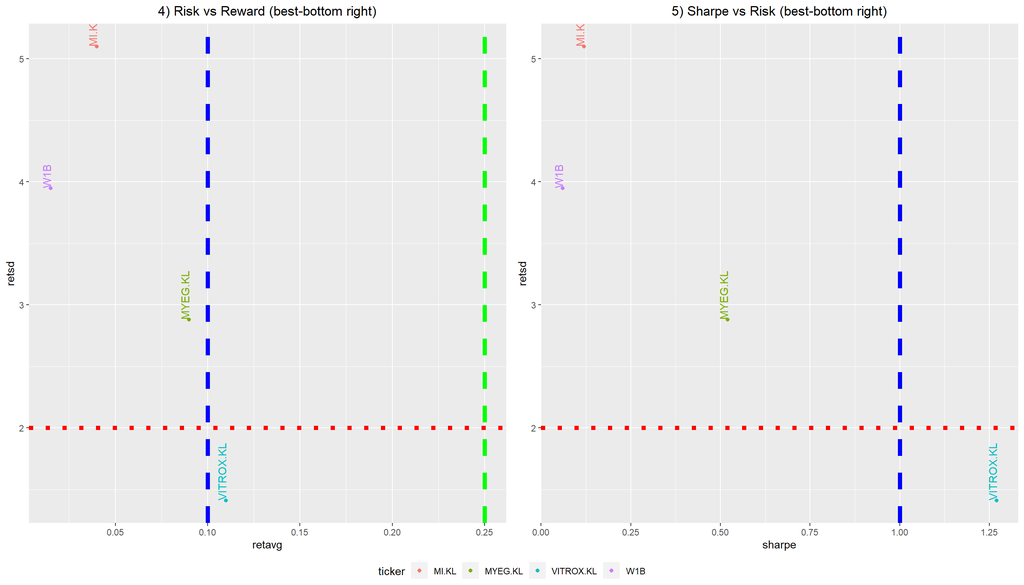

```
##
## $`2`
```

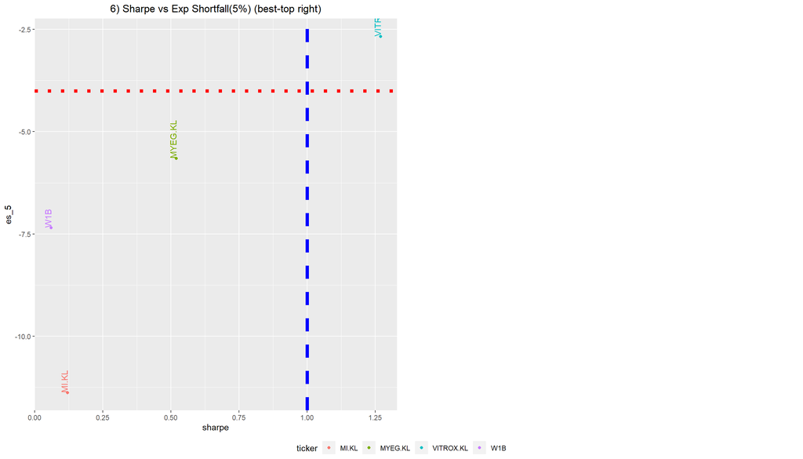

```
##
## attr(,"class")
## [1] "list"      "ggarrange"
```

### 4) Risk Reward (top left)

1. Vitrox shows with promising signs (with low risk and good returns)

### 5) Sharpe vs Risk (top right)

1. Again, Vitrox show promising signs too
2. Others give low returns but high risk (MyEG looks OK)

### 6) - Sharpe vs Expected Shortfall (bottom)

1. Only promising stock is
   - **Vitrox**

## Final Conclusion

1. Only **Vitrox** has potential due to good past performance
2. However its valuation(PE) is very high at more than 40!
3. Consolation, the risk level is low

### DataTable (sharpes_df)

|  | ticker | sharpe | retavg | retsd | totscore | maxdrawdown | close | eps | pe | dy | es_5 | gradient | intercept | sdscore | retscore | shrscore | shr2score | close2score | mddscore | epsscore | pescore | dyscore | investor | favorite | sector | indice | lastprice |
| --- | --- | --- | --- | --- | --- | --- | --- | --- | --- | --- | --- | --- | --- | --- | --- | --- | --- | --- | --- | --- | --- | --- | --- | --- | --- | --- | --- |
| 1 | VITROX.KL | 1.27 | 0.11 | 1.41 | 5 | -30.09 | 8.92 | 19.43 | 45.92 | 0.65 | -2.673 | 0.03 | 7.49 | 1 | 1 | 2 | 1 | 0 | -1 | 1 | 2 | -1 |  | W1B | SEMICON | MC_05 | 8.92 |
| 2 | MYEG.KL | 0.52 | 0.09 | 2.88 | 1 | -41.18 | 1.3 |  | 0 | 1.05 | -5.652 | 0 | 1.13 | 1 | 0 | 1 | 3 | 2 | -1 | 0 | -1 | 1 |  | W1B | PORTAL | XX_01 | 1.3 |
| 3 | MI.KL | 0.12 | 0.04 | 5.1 | 4 | -47.48 | 2.69 | 8.5 | 31.64 | 2.43 | -11.381 | 0 | 2.04 | 1 | 0 | 0 | 1 | 2 | -1 | 1 | 2 | 1 | ESSC,CSC | W1B | SEMICON | SC_010 | 2.69 |
| 4 | SERBADK.KL | -0.58 | -0.19 | 5.12 | 4 | -54.55 | 2.43 | 15.26 | 15.92 | 3.33 | -9.043 | -0.01 | 2.7 | 1 | -1 | -1 | 3 | 2 | -1 | 1 | 3 | 2 | KG1C | W1B | ENERGY-HOT | MC_04 | 2.43 |

#### Comments

1. Top scorers in that group are
   - **Vitrox (5) & good sharpe ratio (imply good reward against risk)**
   - **MyEq, although sharpe shows promising sign but scores the lowest in the group**
2. Look at group performance below
3. Overall performance is poor

### Table (sector_metrics_wdf)

By Sector

| ticker | sharpe | retavg | retsd | pe | dy | eps | es_5 | lastprice | sector |
| --- | --- | --- | --- | --- | --- | --- | --- | --- | --- |
| MI.KL | 0.12 | 0.040 | 5.100 | 31.64 | 2.43 | 8.50 | -11.381 | 2.69 | SEMICON |
| MYEG.KL | 0.52 | 0.090 | 2.880 | 0.00 | 1.05 | NA | -5.652 | 1.30 | PORTAL |
| VITROX.KL | 1.27 | 0.110 | 1.410 | 45.92 | 0.65 | 19.43 | -2.673 | 8.92 | SEMICON |
| W1B | 0.06 | 0.015 | 3.949 | 23.78 | 1.74 | NA | -7.348 | 2.56 | NA |

## Quarter Earning Reports

### Metrics Lm-Lw-Tw

[interactive chart not shown]

#### Comments

1. Total implies ‘Median’
2. Example for SemiCon group
   - **sharpe median = 0.695**
   - **average returns median = 0.075 or 7%**
3. Best stock in the group - Vitrox
   - **last price = 8.92 (21/2/20)**
   - **also overvalued at pe 45**
   - **lowest dividend yields in the group = 0.65**
   - **earning per share = 19.43**